# Analyzing Individual BGG Users

Phil Henrickson

2022-01-01

# **EuroCultAV’s** BoardGameGeek Collection

This notebook contains a set of analyses for the selected user’s boardgamegeek collection. The bulk of the analysis is focused on building a user-specific predictive model to predict the games that EuroCultAV is likely to own. This enables to ask questions like, based on the games the user currently owns, what games are a good fit for their collection? What upcoming games are they likely to purchase?

This analysis is based on data from BoardGameGeek that was last updated on **2021-12-20.**

# 1 Collection Overview

We can look at a basic description of the number of games that the user owns, has rated, has previously owned, etc.

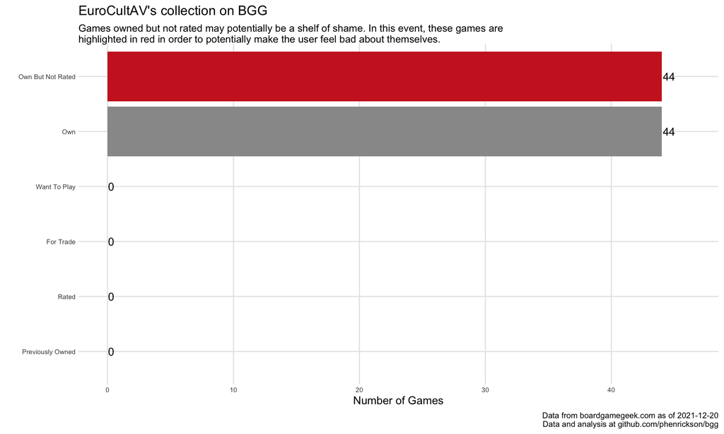

What years has the user owned/rated games from? While we can’t see when a user added or removed a game from their collection, we can look at their collection by the years in which their games were published.

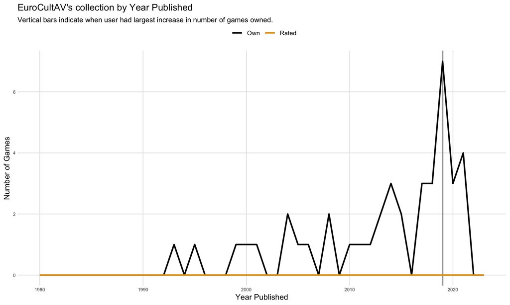

## 1.1 What types of games does EuroCultAV own?

We can look at the most frequent types of categories, mechanics, designers, and artists that appear in a user’s collection.

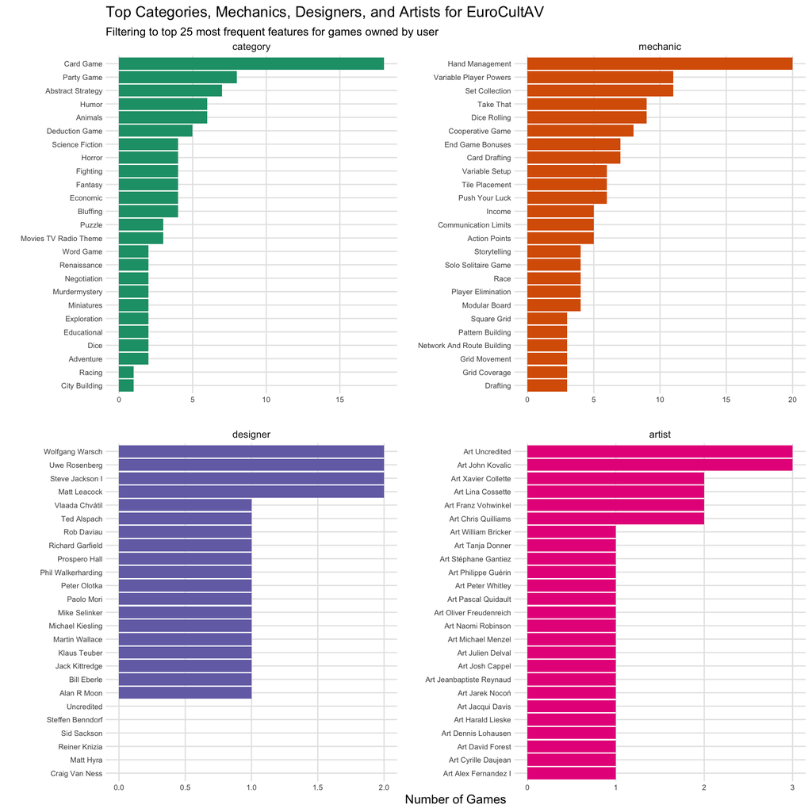

# 2 Modeling **EuroCultAV’s** Collection

| username | dataset | period | games_owned | games_rated | games_played |
| --- | --- | --- | --- | --- | --- |
| EuroCultAV | training | published before 2020 | 37 | 0 | 37 |
| EuroCultAV | test | published 2020 or later | 7 | 0 | 7 |

There are two main (binary) outcomes we will be modeling for the user.

The first, **own** refers to whether the user currently lists a game as owned in their collection. The second, **played** refers to whether the user currently owns, has rated, or previously owned a game. This means the latter will generally have a larger list of games, but may still be a useful category to examine for people who play lots of games without necessarily owning them.

We will train predictive models to learn the probability that the user will own or play individual games based on their features.

## 2.1 Coefficients for EuroCultAV

We can examine coefficients from the trained modes, which are penalized logistic regressions fit to our two main outcomes. Positive values indicate that a feature increases a user’s probabilility of owning/rating a game, while negative values indicate a feature decreases the probability.

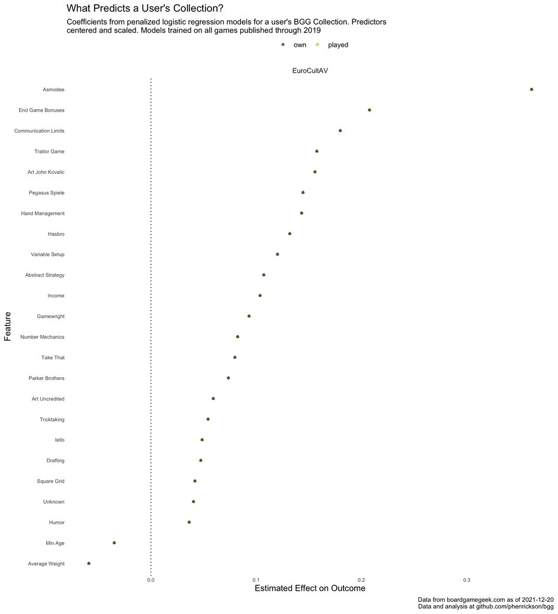

## 2.2 Visualizing Predictors for EuroCultAV’s Collection

Why did the model identify these features? We can make density plots of the important features for predicting whether the user owned a game. Blue indicates the density for games owned by the user, while grey indicates the density for games not owned by the user.

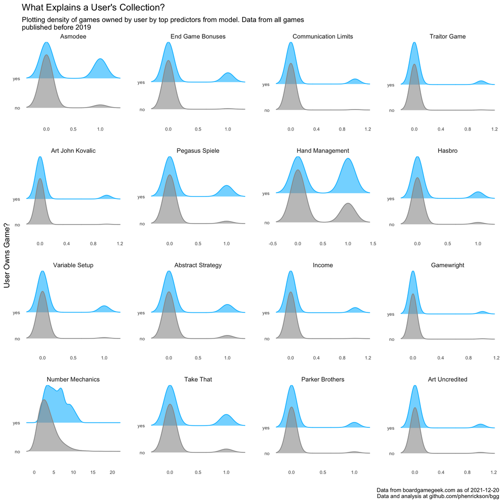

Binary predictors can be difficult to see with this visualization, so we can also directly examine the percentage of games in a user’s collection with a predictor vs the percentage of all games with that predictor.

| username | Feature | % of Games with Feature In_Collection | % of Games with Feature All_Games | Ratio |
| --- | --- | --- | --- | --- |
| EuroCultAV | Income | 10.8% | 0.7% | 15.7 |
| EuroCultAV | End Game Bonuses | 18.9% | 1.2% | 15.6 |
| EuroCultAV | Traitor Game | 8.1% | 0.6% | 12.5 |
| EuroCultAV | Communication Limits | 10.8% | 1.0% | 11.3 |
| EuroCultAV | Drafting | 8.1% | 1.0% | 7.9 |
| EuroCultAV | Variable Setup | 13.5% | 1.9% | 7.3 |
| EuroCultAV | Asmodee | 35.1% | 5.3% | 6.7 |
| EuroCultAV | Square Grid | 8.1% | 1.4% | 5.8 |
| EuroCultAV | Gamewright | 5.4% | 0.9% | 5.7 |
| EuroCultAV | Unknown | 8.1% | 1.5% | 5.5 |
| EuroCultAV | Pegasus Spiele | 21.6% | 4.7% | 4.6 |
| EuroCultAV | Mattel | 5.4% | 1.3% | 4.3 |
| EuroCultAV | Selfpublished | 5.4% | 1.4% | 3.8 |
| EuroCultAV | Parker Brothers | 10.8% | 2.9% | 3.7 |
| EuroCultAV | Hasbro | 13.5% | 3.9% | 3.5 |
| EuroCultAV | Iello | 10.8% | 3.1% | 3.5 |
| EuroCultAV | Take That | 21.6% | 6.6% | 3.3 |
| EuroCultAV | Tricktaking | 5.4% | 1.7% | 3.2 |
| EuroCultAV | Word Game | 5.4% | 1.8% | 3.1 |
| EuroCultAV | Humor | 16.2% | 5.6% | 2.9 |
| EuroCultAV | Horror | 10.8% | 3.9% | 2.7 |
| EuroCultAV | Abstract Strategy | 16.2% | 6.3% | 2.6 |
| EuroCultAV | Push Your Luck | 13.5% | 5.3% | 2.6 |
| EuroCultAV | Hand Management | 48.6% | 26.7% | 1.8 |
| EuroCultAV | Worker Placement | 0.0% | 6.0% | 0.0 |

# 3 Assess Model’s Performance on Training Set

Before predicting games in upcoming years, we can examine how well the model did and what games it liked in the training set. In this case, we used resampling techniques (cross validation) to ensure that the model had not seen a game before making its predictions.

## 3.1 Separation Plot

An easy way to examine the performance of classification model is to view a separation plot. We plot the predicted probabilities from the model for every game (from resampling) from lowest to highest. We then overlay a blue line for any game that the user does own. A good classifier is one that is able to *separate* the blue (games owned by the user) from the white (games not owned by the user), with most of the blue occurring at the highest probabilities (right side of the chart).

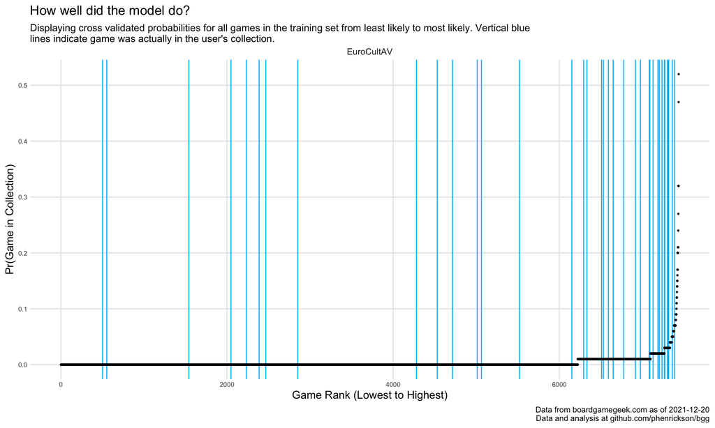

## 3.2 Top Games for **EuroCultAV** from Training Set

We can display this information in table form, displaying the 100 games with the highest probability of ownership, adding a blue line when the user does own the game.

| username | yearpublished | game_id | name | pred_played | pred_own | actual_played | actual_own |
| --- | --- | --- | --- | --- | --- | --- | --- |
| EuroCultAV | 2014 | 156129 | Deception: Murder in Hong Kong | 0.52 | 0.52 | 0 | 0 |
| EuroCultAV | 2018 | 205896 | Rising Sun | 0.47 | 0.47 | 0 | 0 |
| EuroCultAV | 2018 | 244711 | Newton | 0.32 | 0.32 | 0 | 0 |
| EuroCultAV | 2019 | 270971 | Era: Medieval Age | 0.32 | 0.32 | 0 | 0 |
| EuroCultAV | 2019 | 283863 | The Magnificent | 0.27 | 0.27 | 0 | 0 |
| EuroCultAV | 2019 | 276025 | Maracaibo | 0.24 | 0.24 | 0 | 0 |
| EuroCultAV | 1959 | 7688 | Memory | 0.21 | 0.21 | 0 | 0 |
| EuroCultAV | 1968 | 7262 | Top Trumps | 0.21 | 0.21 | 0 | 0 |
| EuroCultAV | 2005 | 18258 | Mission: Red Planet | 0.21 | 0.21 | 0 | 0 |
| EuroCultAV | 2018 | 199792 | Everdell | 0.20 | 0.20 | 0 | 0 |
| EuroCultAV | 2005 | 15062 | Shadows over Camelot | 0.20 | 0.20 | 0 | 0 |
| EuroCultAV | 2013 | 127024 | Room 25 | 0.20 | 0.20 | 0 | 0 |
| EuroCultAV | 2004 | 9220 | Saboteur | 0.20 | 0.20 | 0 | 0 |
| EuroCultAV | 2019 | 251247 | Barrage | 0.17 | 0.17 | 0 | 0 |
| EuroCultAV | 2010 | 62219 | Dominant Species | 0.17 | 0.17 | 0 | 0 |
| EuroCultAV | 2019 | 260710 | Amul | 0.16 | 0.16 | 0 | 0 |
| EuroCultAV | 1900 | 45 | Perudo | 0.15 | 0.15 | 0 | 0 |
| EuroCultAV | 2012 | 120677 | Terra Mystica | 0.15 | 0.15 | 0 | 0 |
| EuroCultAV | 2017 | 220308 | Gaia Project | 0.14 | 0.14 | 0 | 0 |
| EuroCultAV | 2016 | 198773 | Codenames: Pictures | 0.14 | 0.14 | 0 | 0 |
| EuroCultAV | 2016 | 72321 | The Networks | 0.14 | 0.14 | 0 | 0 |
| EuroCultAV | 2018 | 225694 | Decrypto | 0.13 | 0.13 | 0 | 0 |
| EuroCultAV | 2018 | 247763 | Underwater Cities | 0.12 | 0.12 | 0 | 0 |
| EuroCultAV | 2011 | 70919 | Takenoko | 0.12 | 0.12 | 0 | 0 |
| EuroCultAV | 2012 | 129622 | Love Letter | 0.12 | 0.12 | 0 | 0 |
| EuroCultAV | 2012 | 107635 | Kairo | 0.11 | 0.11 | 0 | 0 |
| EuroCultAV | 2019 | 245655 | The King's Dilemma | 0.11 | 0.11 | 0 | 0 |
| EuroCultAV | 2014 | 166384 | Spyfall | 0.10 | 0.10 | 0 | 0 |
| EuroCultAV | 2015 | 181687 | The Pursuit of Happiness | 0.09 | 0.09 | 0 | 0 |
| EuroCultAV | 2016 | 176083 | Hit Z Road | 0.09 | 0.09 | 0 | 0 |

[output cut: 70 more lines]

We can also more formally assess how well the model did in resampling by looking at the area under the receiver operating characteristic. A perfect model would receive a score of 1, while a model that cannot predict the outcome will default to a score of 0.5. The extent to which something is a *good* score depends on the setting, but generally anything in the .8 to .9 range is very good while the .7 to .8 range is perfectly acceptable.

| username | outcome_type | .metric | .estimator | .estimate |
| --- | --- | --- | --- | --- |
| EuroCultAV | own | roc_auc | binary | 0.825 |
| EuroCultAV | played | roc_auc | binary | 0.825 |

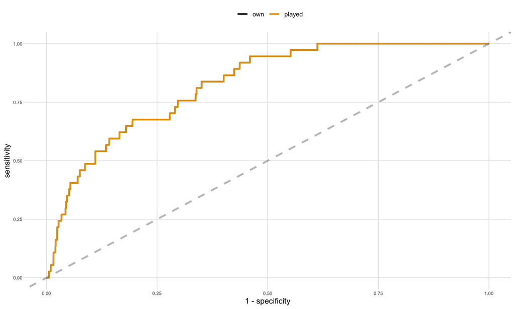

Another way to think about the model performance is to view its lift, or its ability to detect the positive outcomes over that of a null model. High lift indicates the model can much more quickly find all of the positive outcomes (in this case, games owned or played by the user), while a model with no lift is no better than random guessing.

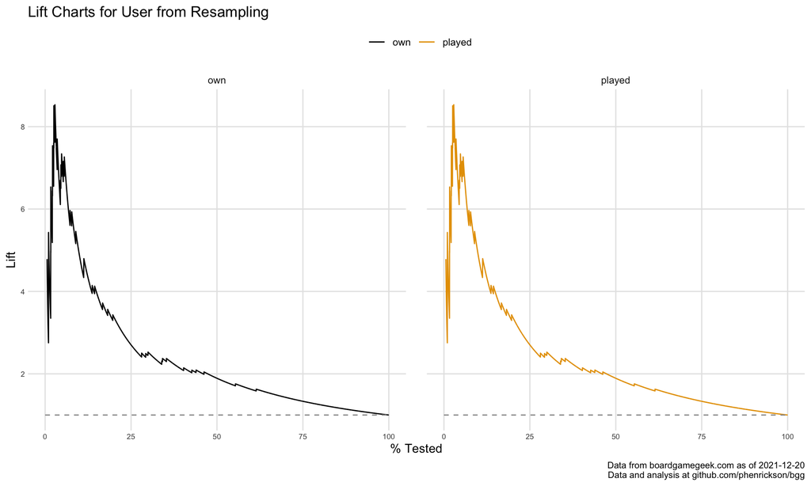

## 3.3 Most and Least Likely Games

What games does the model think EuroCultAV is **most likely to own** that are **not** in their collection?

| username | yearpublished | game_id | name | pred_own | actual_own |
| --- | --- | --- | --- | --- | --- |
| EuroCultAV | 2014 | 156129 | Deception: Murder in Hong Kong | 0.52 | 0 |
| EuroCultAV | 2018 | 205896 | Rising Sun | 0.47 | 0 |
| EuroCultAV | 2018 | 244711 | Newton | 0.32 | 0 |
| EuroCultAV | 2019 | 270971 | Era: Medieval Age | 0.32 | 0 |
| EuroCultAV | 2019 | 283863 | The Magnificent | 0.27 | 0 |

What games does the model think EuroCultAV is **least likely to own** that **are** in their collection?

| username | yearpublished | game_id | name | pred_own | actual_own |
| --- | --- | --- | --- | --- | --- |
| EuroCultAV | 2012 | 122298 | Morels | 0 | 1 |
| EuroCultAV | 2017 | 221965 | The Fox in the Forest | 0 | 1 |
| EuroCultAV | 2005 | 12692 | Gloom | 0 | 1 |
| EuroCultAV | 2006 | 25669 | Qwirkle | 0 | 1 |
| EuroCultAV | 2018 | 244521 | The Quacks of Quedlinburg | 0 | 1 |

## 3.4 Top Games by Year

Top 25 games most likely to be owned by the user in each year, highlighting in blue the games that the user has owned/played.

| rank | 2011 | 2012 | 2013 | 2014 | 2015 | 2016 | 2017 | 2018 | 2019 |
| --- | --- | --- | --- | --- | --- | --- | --- | --- | --- |
| 1 | Takenoko | Terra Mystica | Room 25 | Deception: Murder in Hong Kong | The Pursuit of Happiness | Codenames: Pictures | Gaia Project | Rising Sun | Era: Medieval Age |
| 2 | Mage Knight Board Game | Love Letter | Concept | Spyfall | Salem 1692 | The Networks | Photosynthesis | Newton | The Magnificent |
| 3 | Tetris Link | Kairo | Legacy: The Testament of Duke de Crecy | Five Tribes | Mysterium | Hit Z Road | Codenames: Disney – Family Edition | Everdell | Maracaibo |
| 4 | Tragedy Looper | Munchkin Conan | Ultimate Werewolf: Inquisition | Witness | Smash Up: Munchkin | Codenames: Deep Undercover | Paper Tales | Decrypto | Barrage |
| 5 | Timeline: Discoveries | Archipelago | Prosperity | Istanbul | Grand Austria Hotel | Terraforming Mars | Codenames: Duet | Underwater Cities | Amul |
| 6 | Rory's Story Cubes: Voyages | Keyflower | Cappuccino | Camel Up | The King Is Dead | 13 Days: The Cuban Missile Crisis | Gloomhaven | Azul: Stained Glass of Sintra | The King's Dilemma |
| 7 | Munchkin Zombies | Seasons | Spyrium | Spurs: A Tale in the Old West | Exploding Kittens: NSFW Deck | Citadels | Bears vs Babies | Kero | One Key |
| 8 | Flash Point: Fire Rescue | Munchkin Apocalypse | Tales & Games: The Three Little Pigs | Dead of Winter: A Crossroads Game | Munchkin Gloom | New Angeles | Fog of Love | Gingerbread House | Last Bastion |
| 9 | Munchkin Axe Cop | Suburbia | Smash Up: The Obligatory Cthulhu Set | Patchwork | Munchkin Oz | Clank!: A Deck-Building Adventure | Azul | Coimbra | Clank!: Legacy – Acquisitions Incorporated |
| 10 | Rumble in the House | Kill the Overlord | Tajemnicze Domostwo | La Granja | Blood Rage | When I Dream | Pulsar 2849 | Duelosaur Island | Yukon Airways |
| 11 | A Few Acres of Snow | One Night Werewolf | Cardline: Globetrotter | Alchemists | The Bloody Inn | Sushi Go Party! | Outlive | Codenames: Harry Potter | Minecraft: Builders & Biomes |
| 12 | Ascension: Return of the Fallen | Libertalia | Munchkin Pathfinder | Ultimate Werewolf | The Voyages of Marco Polo | Yokohama | Magic Maze | Blue Lagoon | Black Angel |
| 13 | Streams | Dixit: Journey | Bomb Squad | Munchkin Panic | Codenames | Secret Hitler | Exploding Kittens: Party Pack | Human Punishment: Social Deduction 2.0 | Silver & Gold |
| 14 | Space Empires: 4X | Rumble in the Dungeon | Munchkin Legends | Onitama | One Night Ultimate Werewolf: Daybreak | Inis | Mountains of Madness | Gizmos | Tiny Towns |
| 15 | The Secret of Monte Cristo | Coup | Crossing | Red7 | ...and then, we held hands. | Dead of Winter: The Long Night | Smash Up: What Were We Thinking? | The Grizzled: Armistice Edition | Letter Jam |
| 16 | Discworld: Ankh-Morpork | The Resistance: Avalon | Brew Crafters | Outfoxed! | Haspelknecht | Great Western Trail | Dinosaur Island | Century: Eastern Wonders | Ragusa |
| 17 | Pastiche | Tokaido | Dungeon Twister: The Card Game | Ultimate Werewolf: Deluxe Edition | Risk: Europe | Imhotep | The Thing: Infection at Outpost 31 | Sherlock: The Tomb of the Archaeologist | Crystal Palace |
| 18 | Octopus's Garden | Noah | Smash Up: Awesome Level 9000 | Pictopia: Disney Edition | Far Space Foundry | Dream Home | One Night Ultimate Alien | Sherlock: Death on the 4th of July | KeyForge: Age of Ascension |
| 19 | Fealty | Rent a Hero | The Ravens of Thri Sahashri | Colt Express | Elysium | Islebound | The Godfather: Corleone's Empire | Sherlock: Last Call | Paris: La Cité de la Lumière |
| 20 | Ascension: Storm of Souls | Kemet | Rivet Wars: Eastern Front | Don't Mess with Cthulhu | Barony | Beyond Baker Street | Pendragon: The Fall of Roman Britain | Sherlock: 13 Hostages | Sierra West |
| 21 | Timeline: Events | Neuroshima: Convoy | One Zero One | Dogs of War | Potion Explosion | Assembly | Bunny Kingdom | Sherlock: Paradero Desconocido | MegaCity: Oceania |
| 22 | The Road to Canterbury | PIX | Pizza Party | Sheriff of Nottingham | Tales & Games: The Grasshopper & the Ant | Final Touch | Unstable Unicorns | First Contact | Century: A New World |
| 23 | Dixit: Odyssey | Mice and Mystics | Berserk: War of the Realms | Medieval Academy | Unspeakable Words: Deluxe Edition | Captain Sonar | Betrayal at Baldur's Gate | Ultimate Werewolf Legacy | Pandemic: Rapid Response |
| 24 | Dark Moon | Tzolk'in: The Mayan Calendar | Tash-Kalar: Arena of Legends | Gaïa | Homeland: The Game | Timeline: British History | Calimala | Western Legends | The Menace Among Us |
| 25 | Letters from Whitechapel | Serenissima (Second Edition) | Sorry! with Fire & Ice Power-ups | Heroes of Normandie | The Grizzled | Timebomb | Dungeon Time | Werewords Deluxe Edition | Sherlock: Don's Legacy |

## 3.5 Interactive Predictions from Resampling

Interactive table for predictions from resampling.

|  | username | yearpublished | rank | game_id | name | pred_played | pred_own | actual_played | actual_own |
| --- | --- | --- | --- | --- | --- | --- | --- | --- | --- |
| 1 | EuroCultAV | 1900 | 17 | 45 | Perudo | 0.15 | 0.15 | 0 | 0 |
| 2 | EuroCultAV | 1900 | 52 | 15878 | Rummy | 0.07 | 0.07 | 0 | 0 |
| 3 | EuroCultAV | 1900 | 107 | 2065 | Shogi | 0.03 | 0.03 | 0 | 0 |
| 4 | EuroCultAV | 1900 | 110 | 2083 | Checkers | 0.03 | 0.03 | 0 | 0 |
| 5 | EuroCultAV | 1900 | 116 | 7316 | Bingo | 0.03 | 0.03 | 0 | 0 |
| 6 | EuroCultAV | 1900 | 155 | 2136 | Pachisi | 0.03 | 0.03 | 0 | 0 |
| 7 | EuroCultAV | 1900 | 156 | 2386 | Chinese Checkers | 0.03 | 0.03 | 0 | 0 |
| 8 | EuroCultAV | 1900 | 173 | 171 | Chess | 0.02 | 0.02 | 0 | 0 |
| 9 | EuroCultAV | 1900 | 177 | 2389 | Othello | 0.02 | 0.02 | 0 | 0 |
| 10 | EuroCultAV | 1900 | 178 | 2397 | Backgammon | 0.02 | 0.02 | 0 | 0 |

[output cut: 7426 more lines]

# 4 Validating the Model on 2020

How well did a model trained on a user’s collection through 2019 perform in predicting games for the user from 2020?

| username | outcome_type | yearpublished | .metric | .estimator | .estimate |
| --- | --- | --- | --- | --- | --- |
| EuroCultAV | own | 2020 | roc_auc | binary | 0.683 |
| EuroCultAV | played | 2020 | roc_auc | binary | 0.683 |

Table of top 25 games from 2020, highlighting games that the user owns.

| username | yearpublished | game_id | name | pred_own | pred_played | actual_own | actual_played |
| --- | --- | --- | --- | --- | --- | --- | --- |
| EuroCultAV | 2020 | 184267 | On Mars | 0.10 | 0.10 | 0 | 0 |
| EuroCultAV | 2020 | 256317 | Guild Master | 0.10 | 0.10 | 0 | 0 |
| EuroCultAV | 2020 | 291457 | Gloomhaven: Jaws of the Lion | 0.10 | 0.10 | 0 | 0 |
| EuroCultAV | 2020 | 308765 | Praga Caput Regni | 0.10 | 0.10 | 0 | 0 |
| EuroCultAV | 2020 | 257001 | Munchkin Dungeon | 0.06 | 0.06 | 0 | 0 |
| EuroCultAV | 2020 | 300322 | Hallertau | 0.06 | 0.06 | 0 | 0 |
| EuroCultAV | 2020 | 301767 | Mysterium Park | 0.06 | 0.06 | 1 | 1 |
| EuroCultAV | 2020 | 319966 | The King Is Dead: Second Edition | 0.06 | 0.06 | 0 | 0 |
| EuroCultAV | 2020 | 320819 | Dinner in Paris | 0.06 | 0.06 | 0 | 0 |
| EuroCultAV | 2020 | 291874 | Dwergar | 0.05 | 0.05 | 0 | 0 |
| EuroCultAV | 2020 | 297204 | Traintopia | 0.05 | 0.05 | 0 | 0 |
| EuroCultAV | 2020 | 298352 | The Shining | 0.05 | 0.05 | 0 | 0 |
| EuroCultAV | 2020 | 298371 | Wild Space | 0.04 | 0.04 | 0 | 0 |
| EuroCultAV | 2020 | 300081 | Hideous Abomination | 0.04 | 0.04 | 0 | 0 |
| EuroCultAV | 2020 | 307002 | Regicide | 0.04 | 0.04 | 0 | 0 |
| EuroCultAV | 2020 | 311193 | Anno 1800 | 0.04 | 0.04 | 0 | 0 |
| EuroCultAV | 2020 | 277927 | Bites | 0.03 | 0.03 | 0 | 0 |
| EuroCultAV | 2020 | 288169 | The Fox in the Forest Duet | 0.03 | 0.03 | 0 | 0 |
| EuroCultAV | 2020 | 299592 | Beez | 0.03 | 0.03 | 0 | 0 |
| EuroCultAV | 2020 | 299939 | Doodle Dungeon | 0.03 | 0.03 | 0 | 0 |
| EuroCultAV | 2020 | 246900 | Eclipse: Second Dawn for the Galaxy | 0.02 | 0.02 | 0 | 0 |
| EuroCultAV | 2020 | 288513 | Tranquility | 0.02 | 0.02 | 0 | 0 |
| EuroCultAV | 2020 | 292333 | Cowboys II: Cowboys & Indians Edition | 0.02 | 0.02 | 0 | 0 |
| EuroCultAV | 2020 | 296151 | Viscounts of the West Kingdom | 0.02 | 0.02 | 0 | 0 |
| EuroCultAV | 2020 | 296892 | Sacred Rites | 0.02 | 0.02 | 0 | 0 |

# 5 Predicting Upcoming Games (2020 and On) for **EuroCultAV**

Examine the top games for the test set.

| username | yearpublished | game_id | name | rank | own | played |
| --- | --- | --- | --- | --- | --- | --- |
| EuroCultAV | 2020 | 308765 | Praga Caput Regni | 1 | 0.10 | 0.10 |
| EuroCultAV | 2020 | 184267 | On Mars | 2 | 0.10 | 0.10 |
| EuroCultAV | 2020 | 291457 | Gloomhaven: Jaws of the Lion | 3 | 0.10 | 0.10 |
| EuroCultAV | 2020 | 256317 | Guild Master | 4 | 0.10 | 0.10 |
| EuroCultAV | 2020 | 257001 | Munchkin Dungeon | 5 | 0.06 | 0.06 |
| EuroCultAV | 2020 | 301767 | Mysterium Park | 6 | 0.06 | 0.06 |
| EuroCultAV | 2020 | 300322 | Hallertau | 7 | 0.06 | 0.06 |
| EuroCultAV | 2020 | 320819 | Dinner in Paris | 8 | 0.06 | 0.06 |
| EuroCultAV | 2020 | 319966 | The King Is Dead: Second Edition | 9 | 0.06 | 0.06 |
| EuroCultAV | 2020 | 297204 | Traintopia | 10 | 0.05 | 0.05 |
| EuroCultAV | 2020 | 291874 | Dwergar | 11 | 0.05 | 0.05 |
| EuroCultAV | 2020 | 298352 | The Shining | 12 | 0.05 | 0.05 |
| EuroCultAV | 2020 | 311193 | Anno 1800 | 13 | 0.04 | 0.04 |
| EuroCultAV | 2020 | 300081 | Hideous Abomination | 14 | 0.04 | 0.04 |
| EuroCultAV | 2020 | 307002 | Regicide | 15 | 0.04 | 0.04 |
| EuroCultAV | 2020 | 298371 | Wild Space | 16 | 0.04 | 0.04 |
| EuroCultAV | 2020 | 288169 | The Fox in the Forest Duet | 17 | 0.03 | 0.03 |
| EuroCultAV | 2020 | 299939 | Doodle Dungeon | 18 | 0.03 | 0.03 |
| EuroCultAV | 2020 | 299592 | Beez | 19 | 0.03 | 0.03 |
| EuroCultAV | 2020 | 277927 | Bites | 20 | 0.03 | 0.03 |
| EuroCultAV | 2020 | 313817 | Hello Neighbor: The Secret Neighbor Party Game | 21 | 0.02 | 0.02 |
| EuroCultAV | 2020 | 312786 | Poetry for Neanderthals | 22 | 0.02 | 0.02 |
| EuroCultAV | 2020 | 307997 | Insider Black | 23 | 0.02 | 0.02 |
| EuroCultAV | 2020 | 297735 | Disciple Detective | 24 | 0.02 | 0.02 |
| EuroCultAV | 2020 | 246900 | Eclipse: Second Dawn for the Galaxy | 25 | 0.02 | 0.02 |
| EuroCultAV | 2021 | 298102 | Roll Camera!: The Filmmaking Board Game | 1 | 0.30 | 0.30 |
| EuroCultAV | 2021 | 331635 | Kameloot | 2 | 0.13 | 0.13 |
| EuroCultAV | 2021 | 342942 | Ark Nova | 3 | 0.13 | 0.13 |
| EuroCultAV | 2021 | 310873 | Carnegie | 4 | 0.13 | 0.13 |
| EuroCultAV | 2021 | 343905 | Boonlake | 5 | 0.11 | 0.11 |
| EuroCultAV | 2021 | 290618 | Wishland | 6 | 0.09 | 0.09 |
| EuroCultAV | 2021 | 291847 | Mantis Falls | 7 | 0.08 | 0.08 |
| EuroCultAV | 2021 | 340466 | Unfathomable | 8 | 0.08 | 0.08 |
| EuroCultAV | 2021 | 298383 | Golem | 9 | 0.07 | 0.07 |
| EuroCultAV | 2021 | 329002 | CULTivate | 10 | 0.07 | 0.07 |
| EuroCultAV | 2021 | 291859 | Riftforce | 11 | 0.06 | 0.06 |
| EuroCultAV | 2021 | 317504 | Mandala Stones | 12 | 0.05 | 0.05 |
| EuroCultAV | 2021 | 318322 | Hidden Strike: American Revolution | 13 | 0.05 | 0.05 |
| EuroCultAV | 2021 | 320446 | Corduba 27 a.C. | 14 | 0.05 | 0.05 |
| EuroCultAV | 2021 | 318182 | Imperium: Legends | 15 | 0.04 | 0.04 |
| EuroCultAV | 2021 | 327971 | Hippocrates | 16 | 0.04 | 0.04 |
| EuroCultAV | 2021 | 318184 | Imperium: Classics | 17 | 0.04 | 0.04 |
| EuroCultAV | 2021 | 332944 | Sobek: 2 Players | 18 | 0.04 | 0.04 |
| EuroCultAV | 2021 | 326804 | Rorschach | 19 | 0.03 | 0.03 |
| EuroCultAV | 2021 | 319999 | Dungeon Decorators | 20 | 0.03 | 0.03 |
| EuroCultAV | 2021 | 267333 | Goetia: Nine Kings of Solomon | 21 | 0.03 | 0.03 |
| EuroCultAV | 2021 | 289550 | Lions of Lydia | 22 | 0.03 | 0.03 |
| EuroCultAV | 2021 | 330608 | Cryo | 23 | 0.02 | 0.02 |
| EuroCultAV | 2021 | 316287 | Quest | 24 | 0.02 | 0.02 |
| EuroCultAV | 2021 | 238799 | Messina 1347 | 25 | 0.02 | 0.02 |
| EuroCultAV | 2022 | 317511 | Tindaya | 1 | 0.21 | 0.21 |
| EuroCultAV | 2022 | 331106 | The Witcher: Old World | 2 | 0.04 | 0.04 |
| EuroCultAV | 2022 | 345868 | Federation | 3 | 0.03 | 0.03 |
| EuroCultAV | 2022 | 319807 | Shogun no Katana | 4 | 0.03 | 0.03 |
| EuroCultAV | 2022 | 304051 | Creature Comforts | 5 | 0.02 | 0.02 |
| EuroCultAV | 2022 | 324090 | Scarface 1920 | 6 | 0.02 | 0.02 |
| EuroCultAV | 2022 | 336986 | Flamecraft | 7 | 0.02 | 0.02 |
| EuroCultAV | 2022 | 305096 | Endless Winter: Paleoamericans | 8 | 0.02 | 0.02 |
| EuroCultAV | 2022 | 280726 | Legacies | 9 | 0.02 | 0.02 |
| EuroCultAV | 2022 | 295770 | Frosthaven | 10 | 0.02 | 0.02 |
| EuroCultAV | 2022 | 283137 | Human Punishment: The Beginning | 11 | 0.02 | 0.02 |
| EuroCultAV | 2022 | 340325 | Vagrantsong | 12 | 0.01 | 0.01 |
| EuroCultAV | 2022 | 331401 | Dog Park | 13 | 0.01 | 0.01 |
| EuroCultAV | 2022 | 256680 | Return to Dark Tower | 14 | 0.01 | 0.01 |
| EuroCultAV | 2022 | 330950 | Age of Galaxy | 15 | 0.01 | 0.01 |
| EuroCultAV | 2022 | 299106 | Fractal: Beyond the Void | 16 | 0.01 | 0.01 |
| EuroCultAV | 2022 | 342246 | Feuding Foodies | 17 | 0.01 | 0.01 |
| EuroCultAV | 2022 | 338067 | 6: Siege – The Board Game | 18 | 0.01 | 0.01 |
| EuroCultAV | 2022 | 295895 | Distilled | 19 | 0.01 | 0.01 |
| EuroCultAV | 2022 | 334065 | Verdant | 20 | 0.01 | 0.01 |
| EuroCultAV | 2022 | 284189 | Foundations of Rome | 21 | 0.01 | 0.01 |
| EuroCultAV | 2022 | 326945 | Castles of Mad King Ludwig: Collector's Edition | 22 | 0.01 | 0.01 |
| EuroCultAV | 2022 | 335427 | Wild: Serengeti | 23 | 0.01 | 0.01 |
| EuroCultAV | 2022 | 295374 | Long Shot: The Dice Game | 24 | 0.01 | 0.01 |
| EuroCultAV | 2022 | 286158 | D.E.I.: Divide et Impera | 25 | 0.00 | 0.00 |

## 5.1 Interactive Table for Upcoming Games 2020 and On

|  | username | yearpublished | game_id | name | rank | own | played |
| --- | --- | --- | --- | --- | --- | --- | --- |
| 1 | EuroCultAV | 2021 | 298102 | Roll Camera!: The Filmmaking Board Game | 1 | 0.3 | 0.3 |
| 2 | EuroCultAV | 2022 | 317511 | Tindaya | 2 | 0.21 | 0.21 |
| 3 | EuroCultAV | 2021 | 331635 | Kameloot | 3 | 0.13 | 0.13 |
| 4 | EuroCultAV | 2021 | 342942 | Ark Nova | 4 | 0.13 | 0.13 |
| 5 | EuroCultAV | 2021 | 310873 | Carnegie | 5 | 0.13 | 0.13 |
| 6 | EuroCultAV | 2021 | 343905 | Boonlake | 6 | 0.11 | 0.11 |
| 7 | EuroCultAV | 2020 | 308765 | Praga Caput Regni | 7 | 0.1 | 0.1 |
| 8 | EuroCultAV | 2020 | 184267 | On Mars | 8 | 0.1 | 0.1 |
| 9 | EuroCultAV | 2020 | 291457 | Gloomhaven: Jaws of the Lion | 9 | 0.1 | 0.1 |
| 10 | EuroCultAV | 2020 | 256317 | Guild Master | 10 | 0.1 | 0.1 |

[output cut: 1627 more lines]